# Train Word Vector By Yourself (Part One)

Yuqing Jin 金昱清

2024-12-13

## 简介

之前给大家介绍的都是使用**预训练**好的大规模语料库进行研究。  
但是，当我们想要研究特定群体、特定时间、特定主题的语料库时，应该如何操作？  
本部分代码主要展示如何使用已经获取的语料实现**自训练**词向量。  
下一部分将讨论如何使用爬虫技术获取特定的大规模语料库。  
本部分代码主要分为以下部分：

1. 中文分词的基本原理
2. 运用Python-Jieba实现中文分词
3. 利用分词结果实现词向量训练

**Reference:**  
Bao, H.-W.-S. (2022). PsychWordVec: Word embedding research framework for psychological science. https://CRAN.R-project.org/package=PsychWordVec

## 1. 中文分词的基本原理

（作者本人也基本没有懂，所以本部分听听就好）  
假设我们有这样一句话，如何让机器进行分词？

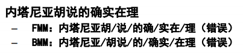

**第一种方法：机械分词（查词典）**  
预先设定一个词典，然后通过从左到右扫描的方式，匹配词典中的词。  
好做，但精度很低。  
**第二种方法：统计分词（马尔可夫假设）**  
统计分词的基本原理是计算不同分词结果的最大概率情况，即最优分词结果。

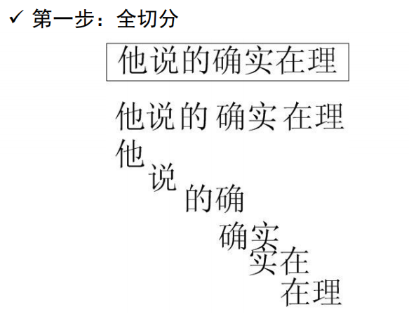

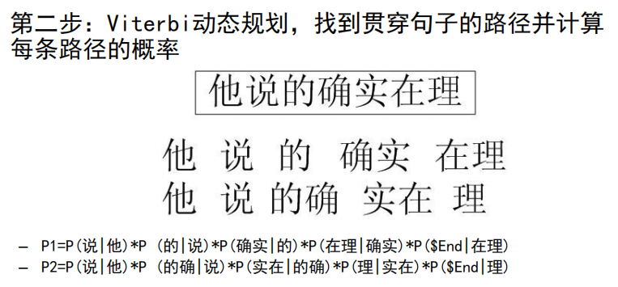

统计分词在实际应用中表现优异，可以胜任大部分分词任务，是目前最常用的方法之一。  
深入原理可以参考：https://zhuanlan.zhihu.com/p/146792308

## 2. Jieba分词应用

**第一步**：在Python环境（或Conda环境）中安装Jieba工具包。  
“win+r”输入cmd，输入以下语句：

```bash
pip install jieba
```

**第二步**：使用Visual Studio Code（或其它类似软件如Spider）打开以下路径文件：  
“…/NLP4Psy/Jieba.py”

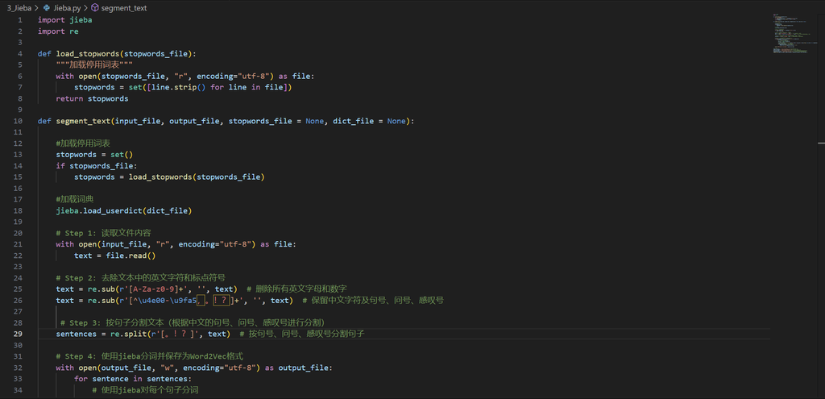

上面这部分代码大家不需要看懂任何句子，只需要找到以下五行：

```python
input_file_path = "./Data/Jieba/Nahan.txt" #需要分词的文件路径
output_file_path = "./Data/Jieba/JiebaResult.txt" #希望输出的文件路径
dict_files_path = "./Data/Jieba/Dict.txt" #指定让jieba默认分词的词语（如不需要可不填）
stopwords_file_path = "./Data/Jieba/Stopwords.txt" #停用词文件路径（如不需要可不填）
segment_text(input_file_path, output_file_path, stopwords_file_path, dict_files_path)
```

在**“input_file_path =”**中，输入你需要进行分词的.txt文件路径名

[figure not shown]

在**“output_file_path”**中，输入你输出分词结果的.txt文件路径

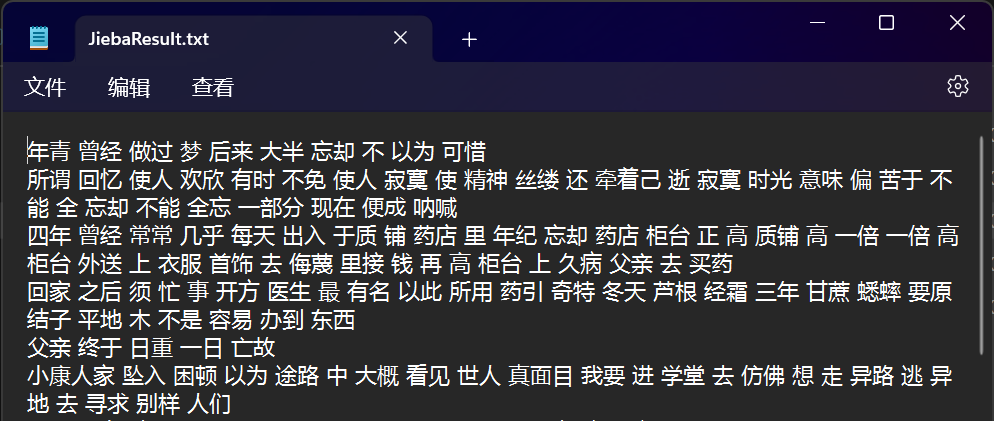

在**“dict_file_path”**中，输入你想让Jieba默认分词的词表.txt文件路径  
例如在进行《呐喊》分词时，设置人名都作为默认词（注意每个词为一行）

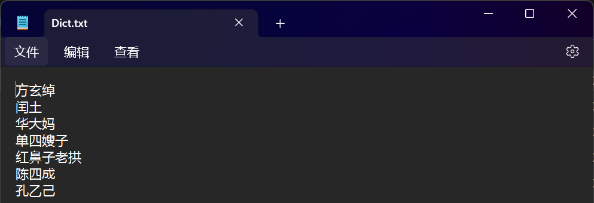

在**“stopwords_file_path”**中，输入停用词，即将特定对自然语言处理用处不大的词忽略  
为大家提供了哈工大的中文停用词表，是目前使用较为广泛的一种。

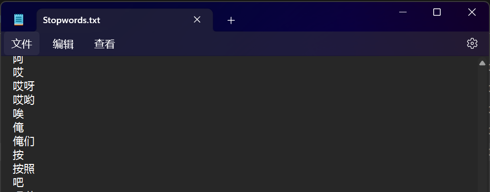

运行代码后即可获得分词完毕的结果。网上有大量Jieba的教程，如有特殊需求大家可以自行学习并更改代码，通过github上传到仓库中进行共享。

## 3. 训练词向量

包寒吴霜老师开发的**“PsychoWordVec”**R包中有自训练词向量的函数**“train_wordvec()”**  
使用时请查询帮助文档：https://psychbruce.github.io/PsychWordVec/reference/train_wordvec.html  
在使用**train_wordvec()**函数时请仔细查看参数，根据研究需要进行设置。  
下面对代码进行简单演示：

```r
#导入必要的R包
if (!requireNamespace('pacman', quietly = TRUE)) {
    install.packages('pacman')
}

pacman::p_load(PsychWordVec,text2vec)

#导入完成分词的文本
text_vector <- readLines("../Data/Jieba/JiebaResult.txt")
text_vector[1:3]
```

```
[1] "年青 曾经 做过 梦 后来 大半 忘却 不 以为 可惜 所谓 回忆 使人 欢欣 有时 不免 使人 寂寞 使 精神 丝缕 还 牵着己 逝 寂寞 时光 意味 偏 苦于 不能 全 忘却 不能 全忘 一部分 现在 便成 呐喊"
[2] "四年 曾经 常常 几乎 每天 出入 于质 铺 药店 里 年纪 忘却 药店 柜台 正 高质 铺 高 一倍 一倍 高 柜台 外送 上 衣服 首饰 去 侮蔑 里接 钱 再 高 柜台 上 久病 父亲 去 买药 回家 之后 须 忙 事 开方 医生 最 有名 以此 所用 药引 奇特 冬天 芦根 经霜 三年 甘蔗 蟋蟀 要原 结子 平地 木多 不是 容易 办到 东西 父亲 终于 日重 一日 亡故"
[3] "小康人家 坠入 困顿 以为 途路 中 大概 看见 世人 真面目 我要 进 学堂 去 仿佛 想 走 异路 逃 异地 去 寻求 别样 人们 母亲 没有 法办 八元 川资 说 自便 伊哭 正是 情理 中 事 读书 应试 正路 所谓 学 洋务 社会 上 便 以为 一种 走投无路 人 只得 灵魂 卖 鬼子 加倍 奚落 排斥 伊 看不见 儿子 顾不得 事 终于 去 进 学堂 学堂 里 才 知道 世上 所谓 格致 算学 地理 历史 绘图 体操 生理学 不教 却 看到 些 木版 全体 新论 化学 卫生 还 记得 先前 医生 议论 方药 现在 知道 比较 起来 便 渐渐 悟 中医 一种 有意 无意 骗…
```

```r
WordVec = train_wordvec(text_vector,
                        method = "word2vec", #预训练的算法
                        dims = 300, #词向量的维度
                        window = 5,
                        min.freq = 5,
                        model = "skip-gram", #Word2Vec模型算法
                        normalize = TRUE, #是否归一化
                        tokenizer = text2vec::space_tokenizer, #按照空格分词，该方法下不要改
                        file.save = "../Data/trainedVec/Nahan.RData")
```

```
✔ Tokenized: 2704 sentences (time cost = 0.1 secs)
```

```
✔ Text corpus: 120481 characters, 66832 tokens (roughly words)
```

```
── Training model information ──────────────────────────────────────────────────
```

```
- Method:      Word2Vec (Skip-Gram with Negative Sampling)
- Dimensions:  300
- Window size: 5 (5 words behind and 5 words ahead the current word)
- Subsampling: 1e-04
- Min. freq.:  5 occurrences in text
- Iterations:  5 training iterations
- CPU threads: 8
```

```
── Training...
```

```
✔ Word vectors trained: 2398 unique tokens (time cost = 0.5 secs)
```

```
Compressing and saving...
```

```
✔ Saved to "../Data/trainedVec/Nahan.RData" (time cost = 0.4 secs)
```

```r
WordVec = as_embed(WordVec)
```

我们可以对训练好的词向量进行一些简单的检查，看看我们训练的词向量质量如何

```r
most_similar(WordVec)
```

```
[Word Vector] =~ <all>
```

```
(normalized to unit length)
```

```
          word cos_sim row_id
 1:       外国  0.9995    987
 2:         猜  0.9994   1420
 3:       不禁  0.9994   1514
 4:       吉光  0.9994   1586
 5:       鼓皮  0.9994   1719
 6:       广漠  0.9994   1887
 7:         俩  0.9994   2145
 8:       恶人  0.9994   2296
 9: 一九二四年  0.9994   2345
10:         皆  0.9994   2366
```

```r
most_similar(WordVec, "孔乙己")
```

```
[Word Vector] =~ 孔乙己
```

```
(normalized to unit length)
```

```
      word cos_sim row_id
 1:     欠  0.9977     97
 2:   喝酒  0.9977    359
 3:   掌柜  0.9977    482
 4:     店  0.9976    517
 5: 第二年  0.9976    722
 6:     散  0.9976    788
 7:   几次  0.9976    895
 8:   上去  0.9975   1315
 9:     算  0.9975   2010
10:   仍然  0.9975   2288
```

似乎不是很好：  
怎么余弦相似度都这么大？  
似乎训练的又很好：  
孔乙己相关的东西确实还行。  
我们要不试试更大的语料库——清华大学自然语言处理实验室：http://thuctc.thunlp.org/

```r
#导入完成分词的文本
text_vectorTH <- readLines("../Data/Jieba/财经.txt")
text_vectorTH[1]
```

```
[1] "新增 资金 入场 沪 胶 强势 创 年内 新高 记者 魏 曙光 本报讯 上海 天然橡胶 期价 周三 再创 年内 新高 主力 合约 突破 元吨 重要 关口 分析师 指出 橡胶 现货 需求 强劲 供应 却 主产 国 降雨 天气 紧俏 国内 有望 出台 新 汽车 刺激 方案 沪 胶 后市 有望 延续 强势 两交易日 强势 调整 后 昨日 上海 天然橡胶 期货价格 再度 大幅 上扬 收盘 前 小时 大量 场外 资金 涌入 主力 合约 强劲 飙升 很快 升穿 元吨 整数 关口 终盘 报收 于元吨 上涨 较前 一日 结算价 上涨 元吨 成交量 为手 持仓量 手 当日 整体 市场 增仓 万余 手 …
```

```r
WordVecTH = train_wordvec(text_vectorTH,
                        method = "word2vec", #预训练的算法
                        dims = 300, #词向量的维度
                        window = 5,
                        min.freq = 10,
                        model = "skip-gram", #Word2Vec模型算法
                        normalize = TRUE, #是否归一化
                        tokenizer = text2vec::space_tokenizer, #按照空格分词，该方法下不要改
                        )
```

```
✔ Tokenized: 37098 sentences (time cost = 7 secs)
```

```
✔ Text corpus: 29799953 characters, 14305031 tokens (roughly words)
```

```
── Training model information ──────────────────────────────────────────────────
```

```
- Method:      Word2Vec (Skip-Gram with Negative Sampling)
- Dimensions:  300
- Window size: 5 (5 words behind and 5 words ahead the current word)
- Subsampling: 1e-04
- Min. freq.:  10 occurrences in text
- Iterations:  5 training iterations
- CPU threads: 8
```

```
── Training...
```

```
✔ Word vectors trained: 45599 unique tokens (time cost = 2 mins)
```

```r
WordVecTH = as_embed(WordVecTH)
```

这次再让我们来检查一下：

```r
most_similar(WordVecTH)
```

```
[Word Vector] =~ <all>
```

```
(normalized to unit length)
```

```
      word cos_sim row_id
 1: 做饭吃  0.7173  34615
 2:   临摹  0.6581  36601
 3:   而已  0.6570  38401
 4: 百美图  0.6554  40630
 5:   油彩  0.6545  40834
 6:   明式  0.6455  42876
 7:   版万  0.6451  43720
 8: 两居室  0.6440  43860
 9:   两辆  0.6430  44718
10:   四少  0.6430  45325
```

```r
most_similar(WordVecTH, "基金")
```

```
[Word Vector] =~ 基金
```

```
(normalized to unit length)
```

```
        word cos_sim row_id
 1:   型基金  0.6708     28
 2:     股票  0.6022     66
 3:     偏股  0.5971    286
 4: 只易方达  0.5907    582
 5:     只且  0.5751  29646
 6:   开放式  0.5716  33083
 7:     率只  0.5601  37401
 8:   嘉实丰  0.5600  39018
 9:   除银华  0.5566  42553
10:     汇封  0.5560  43047
```

好像结果正常多了，于是我们拥有了自己的词向量！

## 注意事项

**关于Jieba分词：**  
1. 本部分提供的Jieba分词是最基础的语句，对于合并处理多个.txt文件的情况，大家可以咨询GPT（亲测有用且高效）。  
2. Jieba分词建议以段落为单位划分，也可以采用句子或篇章为单位划分。但不建议用逗号划分，会损失很多语义信息。  
3. Jieba分词时词典的编制很重要，有些想要研究的词或特定名词请提前标注。  
4. 停用词的采用也会影响语义提取，若非必须可不采用。

**关于预训练模型：**  
1. 语料库规模在百万级以上，多次训练得到的词向量才趋于稳定，因此需要大规模的文本获取(请见下部分爬虫教程)。  
2. 训练词向量的模型方法很多，可以采用多个模型进行交叉验证。  
3. 自训练的词向量对于研究特定主题来说具有优势，但若主题较为宽泛，使用预训练好的词向量是更稳健的选择。

**本部分为初步学习Jieba分词与自训练词向量的经验分享，可能并未完全覆盖实际使用时的需求，如有错误、补充请通过github上传：https://github.com/PsyJin-re/NLP4Psy**  
**Reference:**  
Bao, H.-W.-S. (2022). PsychWordVec: Word embedding research framework for psychological science. https://CRAN.R-project.org/package=PsychWordVec  
部分Jieba代码来源：https://blog.csdn.net/qq_41897800/article/details/113802995  
部分知识来源：中国科学院心理研究所 柏松石